# Data Mapping for Marketing

25 January 2022

## Package used in these slides

```r
library(RColorBrewer)
library(MetBrewer)
library(tidyverse)
library(nFactors)
library(GPArotation)
library(gplots)
library(semPlot)
library(lavaan)
library(semTools)
```

## Colors used in these slides

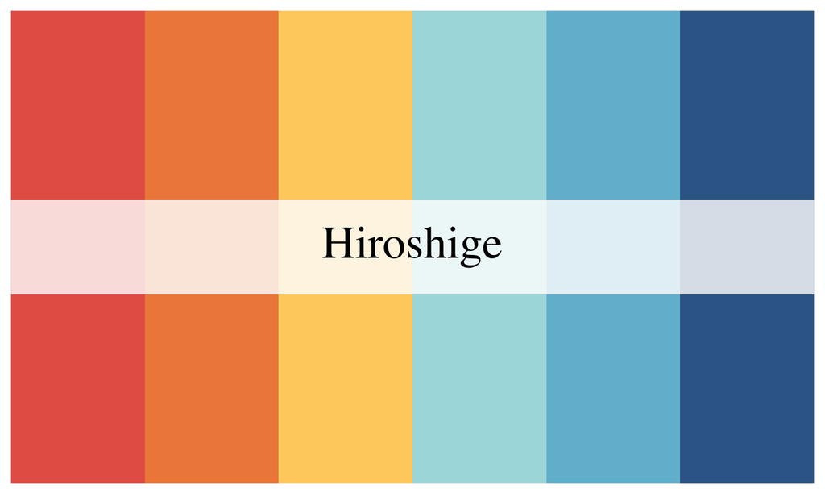

```r
met.brewer("Hiroshige", n=6)
```

## Colors

[figure not shown]

Utagawa Hiroshige

## Data Setup

```r
brand.ratings <- read.csv("http://goo.gl/IQl8nc")
brand.sc <- brand.ratings[, 1:10]
brand.sc[, 1:9] <- data.frame(scale(brand.ratings[, 1:9],
                                    center = TRUE,
                                    scale = TRUE))
```

## Latent Variables

- Variables that are not directly observed by rather inferred from other variables that are observed.
- Examples:
  - Social class
  - Anxiety
  - Satisfaction

## Latent Variables

- Latent variables are often *constructs* (or concepts).
- These are *operationalized* in surveys in the form of observable and measurable components.
- For example, consider designing a survey. What would you want to learn? What would you ask?

## Factor Analysis

- Goal is to reduce a set of variables into a smaller set of factors.
- FA vs. PCA: Emphasis on *interpretability*.
- EFA vs. CFA: Start with data or start with theory?

## EFA benefits

- Reduce dimensions
- Reduce uncertainty
- Reduce data collection

## EFA: nFactors package

```r
factanal(brand.sc[, 1:9],
         factors=2)
```

```
##
## Call:
## factanal(x = brand.sc[, 1:9], factors = 2)
##
## Uniquenesses:
## perform  leader  latest     fun serious bargain   value  trendy   rebuy
##   0.635   0.332   0.796   0.835   0.527   0.354   0.225   0.708   0.585
##
## Loadings:
##         Factor1 Factor2
## perform          0.600
## leader           0.818
## latest  -0.451
## fun     -0.137  -0.382
## serious          0.686
## bargain  0.803
## value    0.873   0.117
## trendy  -0.534
## rebuy    0.569   0.303
##
##                Factor1 Factor2
## SS loadings      2.245   1.759
## Proportion Var   0.249   0.195
## Cumulative Var   0.249   0.445
##
## Test of the hypothesis that 2 factors are sufficient.
## The chi square statistic is 556.19 on 19 degrees of freedom.
## The p-value is 8.66e-106
```

## EFA: nFactors package

- Instead of finding the components that account, in descending order, for the most variance in the data (PCA), EFA finds solutions in which a small number of loadings for each factor are very high, while the rest are low.
- The goal is to find *interpretable* solutions.

## EFA: Pizza Analogy

[figure not shown]

Image by Pizza Masetti Craiova from Craiova, Romania, Wikimedia Commons (https://commons.wikimedia.org/wiki/File:Pizza_with_various_toppings.jpg).

## EFA: How many factors?

### Scree approach

```r
nScree(brand.sc[, 1:9])
```

```
##   noc naf nparallel nkaiser
## 1   3   2         3       3
```

## EFA: How many factors?

### Eigenvalue Approach

```r
eigen(cor(brand.sc[, 1:9]))$values
```

```
## [1] 2.9792956 2.0965517 1.0792549 0.7272110 0.6375459 0.5348432 0.3901044
## [8] 0.3120464 0.2431469
```

## EFA: 2-Factor Solution

```r
brand.fa.test2 <- factanal(brand.sc[, 1:9],
                           factors=2)

brand.fa.test2$loadings
```

```
##
## Loadings:
##         Factor1 Factor2
## perform          0.600
## leader           0.818
## latest  -0.451
## fun     -0.137  -0.382
## serious          0.686
## bargain  0.803
## value    0.873   0.117
## trendy  -0.534
## rebuy    0.569   0.303
##
##                Factor1 Factor2
## SS loadings      2.245   1.759
## Proportion Var   0.249   0.195
## Cumulative Var   0.249   0.445
```

## EFA: 3-Factor Solution

```r
brand.fa <- factanal(brand.sc[, 1:9],
                     factors=3)

brand.fa$loadings
```

```
##
## Loadings:
##         Factor1 Factor2 Factor3
## perform          0.607
## leader           0.810   0.106
## latest  -0.163           0.981
## fun             -0.398   0.205
## serious          0.682
## bargain  0.826          -0.122
## value    0.867          -0.198
## trendy  -0.356           0.586
## rebuy    0.499   0.296  -0.298
##
##                Factor1 Factor2 Factor3
## SS loadings      1.853   1.752   1.510
## Proportion Var   0.206   0.195   0.168
## Cumulative Var   0.206   0.401   0.568
```

## EFA: PCA Comparison

```r
prcomp(brand.sc[, 1:9])
```

```
## Standard deviations (1, .., p=9):
## [1] 1.7260636 1.4479474 1.0388719 0.8527667 0.7984647 0.7313298 0.6245834
## [8] 0.5586112 0.4930993
##
## Rotation (n x k) = (9 x 9):
##                PC1         PC2         PC3         PC4         PC5        PC6
## perform  0.2374679  0.41991179  0.03854006 -0.52630873  0.46793435 -0.3370676
## leader   0.2058257  0.52381901 -0.09512739 -0.08923461 -0.29452974 -0.2968860
## latest  -0.3703806  0.20145317 -0.53273054  0.21410754  0.10586676 -0.1742059
## fun     -0.2510601 -0.25037973 -0.41781346 -0.75063952 -0.33149429  0.1405367
## serious  0.1597402  0.51047254 -0.04067075  0.09893394 -0.55515540  0.3924874
## bargain  0.3991731 -0.21849698 -0.48989756  0.16734345 -0.01257429 -0.1393966
## value    0.4474562 -0.18980822 -0.36924507  0.15118500 -0.06327757 -0.2195327
## trendy  -0.3510292  0.31849032 -0.37090530  0.16764432  0.36649697  0.2658186
## rebuy    0.4390184  0.01509832 -0.12461593 -0.13031231  0.35568769  0.6751400
##                  PC7         PC8         PC9
## perform  0.364179109 -0.14444718  0.05223384
## leader  -0.613674301  0.28766118 -0.17889453
## latest  -0.185480310 -0.64290436  0.05750244
## fun     -0.007114761  0.07461259  0.03153306
## serious  0.445302862 -0.18354764  0.09072231
## bargain  0.288264900  0.05789194 -0.64720849
## value    0.017163011  0.14829295  0.72806108
## trendy   0.153572108  0.61450289  0.05907022
## rebuy   -0.388656160 -0.20210688 -0.01720236
```

## EFA: Exploring results

```r
names(brand.fa)
```

```
##  [1] "converged"    "loadings"     "uniquenesses" "correlation"  "criteria"
##  [6] "factors"      "dof"          "method"       "rotmat"       "STATISTIC"
## [11] "PVAL"         "n.obs"        "call"
```

## EFA: Uniqueness

- The proportion of variability not explained by the factors
- The higher a variable’s uniqueness, the less well the factors account for its variance
- Ranges from 0 to 1

```r
brand.fa$uniquenesses
```

```
##   perform    leader    latest       fun   serious   bargain     value    trendy
## 0.6239890 0.3272841 0.0050000 0.7941232 0.5303783 0.3020242 0.2019618 0.5240309
##     rebuy
## 0.5753600
```

## EFA: Communality

- The proportion of variability that *is* explained by the factors
- Equal to 1 - uniqueness
- Also equal to the sum of the squared loadings
- Ranges from 0 to 1

```r
1 - brand.fa$uniquenesses
```

```
##   perform    leader    latest       fun   serious   bargain     value    trendy
## 0.3760110 0.6727159 0.9950000 0.2058768 0.4696217 0.6979758 0.7980382 0.4759691
##     rebuy
## 0.4246400
```

```r
apply(brand.fa$loadings^2, 1, sum)
```

```
##   perform    leader    latest       fun   serious   bargain     value    trendy
## 0.3760123 0.6727160 0.9950003 0.2058760 0.4696206 0.6979759 0.7980381 0.4759690
##     rebuy
## 0.4246399
```

## EFA: Rotation choices

- Should we force factors be uncorrelated?
- If not, we can choose an *oblique* rotation
- For example, install `GPArotation` package and try:

```r
(brand.fa.ob <- factanal(brand.sc[, 1:9], factors=3, rotation="oblimin"))
```

```
##
## Call:
## factanal(x = brand.sc[, 1:9], factors = 3, rotation = "oblimin")
##
## Uniquenesses:
## perform  leader  latest     fun serious bargain   value  trendy   rebuy
##   0.624   0.327   0.005   0.794   0.530   0.302   0.202   0.524   0.575
##
## Loadings:
##         Factor1 Factor2 Factor3
## perform          0.601
## leader           0.816
## latest                   1.009
## fun             -0.381   0.229
## serious          0.689
## bargain  0.859
## value    0.880
## trendy  -0.267   0.128   0.538
## rebuy    0.448   0.255  -0.226
##
##                Factor1 Factor2 Factor3
## SS loadings      1.789   1.733   1.430
## Proportion Var   0.199   0.193   0.159
## Cumulative Var   0.199   0.391   0.550
##
## Factor Correlations:
##         Factor1 Factor2 Factor3
## Factor1  1.0000  -0.388  0.0368
## Factor2 -0.3884   1.000 -0.1091
## Factor3  0.0368  -0.109  1.0000
##
## Test of the hypothesis that 3 factors are sufficient.
## The chi square statistic is 64.57 on 12 degrees of freedom.
## The p-value is 3.28e-09
```

## Plotting results: Heatmap

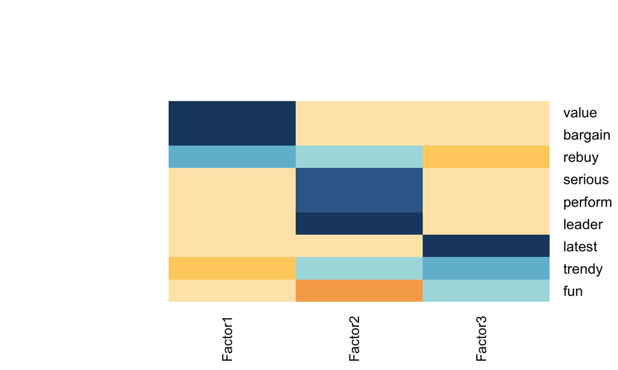

## Plotting results: Heatmap

Code for previous plot:

```r
heatmap.2(brand.fa.ob$loadings,
          col=as.character(met.brewer("Hiroshige", 9)),
          trace="none",
          key=FALSE,
          dend="none",
          Colv=FALSE,
          cexCol = 1.2)
```

## Plotting results: SEM plot

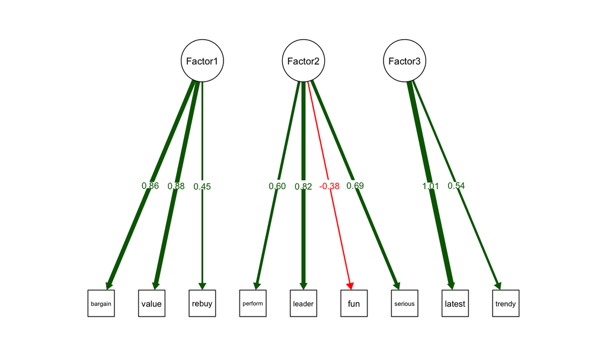

## Plotting results: Path diagram

Code for previous plot:

```r
semPaths(brand.fa.ob, what="est",
         residuals=FALSE,
         cut=0.3, posCol=c("white",
                           "darkgreen"),
         negCol=c("white", "red"),
         edge.label.cex=0.75,
         nCharNodes=7)
```

## EFA: Factor Scores

```r
brand.fa.ob <- factanal(brand.sc[, 1:9],
                        factors=3,
                        rotation="oblimin",
                        scores="Bartlett")

brand.scores <- data.frame(brand.fa.ob$scores)

brand.scores$brand <- brand.sc$brand

head(brand.scores)
```

```
##      Factor1    Factor2    Factor3 brand
## 1  1.6521364 -0.6886749  0.5256104     a
## 2 -1.4005333 -1.6681901 -0.6764121     a
## 3  1.1457311 -1.0618008 -0.4285853     a
## 4  0.2009725 -0.3245462  1.2113424     a
## 5  2.0002009 -1.9071519 -0.4559905     a
## 6  1.4175063  0.3339462  0.8555525     a
```

```r
brand.fa.mean <- aggregate(. ~ brand,
                           data=brand.scores,
                           mean)

rownames(brand.fa.mean) <- brand.fa.mean[, 1] # brand names

brand.fa.mean <- brand.fa.mean[, -1]

names(brand.fa.mean) <- c("Leader", "Value", "Latest") # factor names

brand.fa.mean
```

```
##        Leader       Value      Latest
## a  0.23158792 -1.06993703  0.39326652
## b  0.09686823  1.51913070  0.72391174
## c -0.58937138  1.45069457 -0.07690784
## d -1.04380419 -0.78186861  0.37914638
## e  0.52169760 -0.05373430  0.43709349
## f  1.15218492  0.45442899 -1.28395765
## g  1.36873947  0.04408369 -1.31900029
## h -0.91592078 -0.31418560  0.52676516
## i -0.66918513 -0.20741901  0.37331202
## j -0.15279666 -1.04119340 -0.15362952
```

## EFA: Plotting Factor Scores

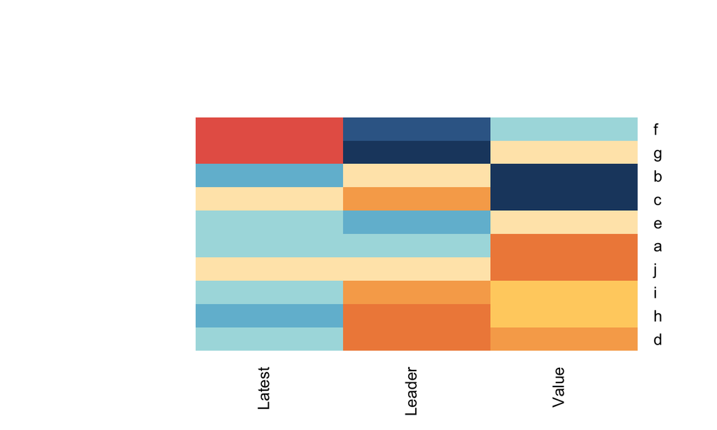

## EFA: Plotting Factor Scores

Code for previous plot:

```r
heatmap.2(as.matrix(brand.fa.mean),
          col=as.character(met.brewer("Hiroshige", 9)),
          trace="none",
          key=FALSE,
          dend="none", cexCol=1.2)
```

## CFA

- We often start with a set of constructs and we want to test how well they are captured by operationalized variables
- This is done frequently when designing surveys

## CFA: PIES Example

Product Involvement and Enthusiasm Scale

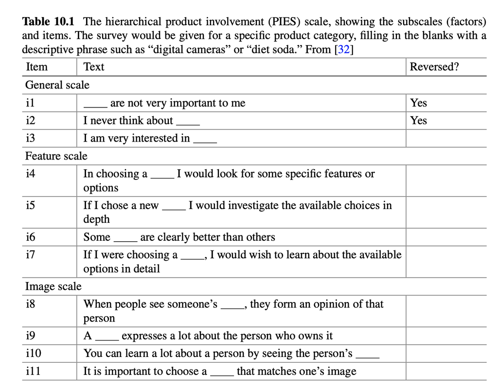

From Chapman & Feit 2019).

## Lab Exercise

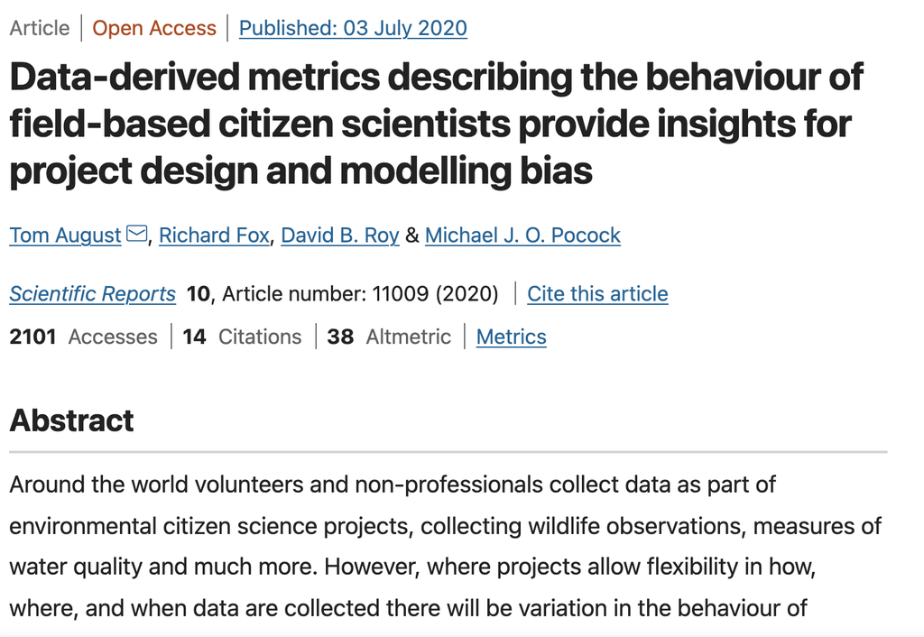

## Lab Exercise

- Skim this article to learn how the authors measured participant behavior in a large citizen science project: https://www.nature.com/articles/s41598-020-67658-3
- Download the data and use PCA and EFA to reduce the dimensionality in order to better understand different types of participant behavior

## Lab Exercise

```r
lab_data = read_csv("https://tinyurl.com/4fbtpdbv")
```

## Lab Exercise

- Incorporating R-output in reports
- Writing reports with R Markdown
- Reference: https://bookdown.org/yihui/rmarkdown/

```r
install.packages("rmarkdown")
```